# Fragilidad bancaria, riesgo de cola del crecimiento y spread soberano

Base final v3 — bbg/Panel_bloomberg.csv (13 países, EMBI Global Diversified)

Mauricio Valenzuela

2026-09-05

# 1 Objetivo

Análisis de regresión de **una sola base** — `bbg/Panel_bloomberg.csv` — sin comparaciones multi-base ni intervenciones intermedias. Es la reconstrucción final del panel ancla en Bloomberg: 13 economías emergentes con EMBI Global Diversified (J.P. Morgan), JLoss (fragilidad bancaria, Merton/KMV + punto de silla) y GaR (cuantil 5 % de crecimiento, panel cuantílico). Reemplaza la versión anterior de este documento (`Panel_final_all17.csv`, 5 países LatAm, controles del paper de JLoss como índices agregados), que quedó superada por esta reconstrucción. Para la batería completa de 24 especificaciones (Tabla 2.3 de la tesis), ver `Regresiones_panel_extended_v3.Rmd` — este documento es el complementario: un núcleo más compacto (M1-M5) con diagnósticos formales (Hausman, VIF) y una robustez más profunda por especificación.

La hipótesis central es la **complementariedad supra-aditiva**: el efecto de la fragilidad bancaria (`JLoss`) sobre el spread soberano (`EMBI_bps`) se intensifica cuando el riesgo de cola del crecimiento es más severo (`GaR` más negativo). El parámetro de interés es θ, el coeficiente de la interacción `JLoss × GaR`.

```r
# install.packages(c("plm","lmtest","sandwich","modelsummary","ggplot2",
#                    "dplyr","tidyr","car","kableExtra"))
library(plm)
library(lmtest)
library(sandwich)
library(modelsummary)
library(ggplot2)
library(dplyr)
library(tidyr)
library(car)
library(kableExtra)

BASE_FILE <- "bbg/Panel_bloomberg.csv"   # <-- única base que lee este documento

prep <- function(path) {
  d <- read.csv(path, stringsAsFactors = FALSE)
  d$year <- as.integer(substr(d$quarter, 1, 4))
  d$q    <- as.integer(substr(d$quarter, 6, 6))
  d$tnum <- d$year + (d$q - 1) / 4
  d <- d[order(d$country, d$tnum), ]
  d$GaR_pp <- d$GaR * 100                       # GaR en puntos porcentuales
  d$ES_pp  <- if ("ES" %in% names(d)) d$ES * 100 else NA
  center   <- function(x) x - mean(x, na.rm = TRUE)
  d$JLoss_c <- center(d$JLoss)                  # centrado -> efectos principales interpretables en la media
  d$GaR_c   <- center(d$GaR_pp)
  d$JxG_c   <- d$JLoss_c * d$GaR_c              # interacción centrada
  d$lnEMBI  <- log(d$EMBI_bps)
  d$post2020 <- as.integer(d$year >= 2020)
  d
}

# Muestra de estimación: EMBI + JLoss + GaR disponibles simultáneamente. Argentina, Egipto,
# Rusia y Pakistán tienen JLoss pero no EMBI ni (en tres de ellos) GaR -- "sin serie" en
# bbg/cobertura_panel_bbg.csv -- y por eso no entran acá.
dat <- prep(BASE_FILE)
dat <- subset(dat, !is.na(EMBI_bps) & !is.na(JLoss) & !is.na(GaR))
dat$country <- factor(dat$country)
pan <- pdata.frame(dat, index = c("country", "tnum"))

# Errores estándar Driscoll-Kraay (robustos a dependencia transversal y autocorrelación)
DK <- function(m) vcovSCC(m, type = "HC1", maxlag = NULL)

CTRL <- "debt_gdp + fisc_bal + res_gdp + ca_gdp + infl_yoy + reer"

cat("Base:", BASE_FILE, "| países:", length(unique(dat$country)),
    "| obs:", nrow(dat), "| rango:", min(dat$quarter), "-", max(dat$quarter), "\n")
```

```
## Base: bbg/Panel_bloomberg.csv | países: 13 | obs: 721 | rango: 2004Q1 - 2026Q1
```

# 2 Cobertura del panel

```r
cov <- dat %>%
  group_by(country) %>%
  summarise(n = n(), desde = min(quarter), hasta = max(quarter), .groups = "drop") %>%
  arrange(desc(n))
kable(cov, caption = "Cobertura por país (muestra de estimación: EMBI+JLoss+GaR)") %>%
  kable_styling(full_width = FALSE, font_size = 12)
```

Cobertura por país (muestra de estimación: EMBI+JLoss+GaR)

| country | n | desde | hasta |
| --- | --- | --- | --- |
| poland | 89 | 2004Q1 | 2026Q1 |
| china | 79 | 2006Q3 | 2026Q1 |
| mexico | 77 | 2006Q4 | 2025Q4 |
| brazil | 75 | 2007Q3 | 2026Q1 |
| chile | 75 | 2007Q3 | 2026Q1 |
| colombia | 70 | 2008Q4 | 2026Q1 |
| peru | 66 | 2009Q4 | 2026Q1 |
| turkey | 63 | 2010Q3 | 2026Q1 |
| india | 54 | 2012Q4 | 2026Q1 |
| malaysia | 40 | 2016Q2 | 2026Q1 |
| indonesia | 11 | 2023Q3 | 2026Q1 |
| philippines | 11 | 2023Q3 | 2026Q1 |
| southafrica | 11 | 2023Q3 | 2026Q1 |

```r
# El GaR viene NA en los primeros trimestres de entrenamiento de cada país
# (n_train insuficiente) y sale de las regresiones vía na.omit. Reportamos la
# cobertura EFECTIVA (GaR no-NA), no solo las filas del CSV.
eff <- dat %>%
  group_by(country) %>%
  summarise(n_filas = n(), n_GaR_valido = sum(!is.na(GaR)), .groups = "drop") %>%
  filter(n_filas != n_GaR_valido)
if (nrow(eff) > 0) {
  kable(eff, caption = "Filas con GaR faltante (excluidas de las regresiones vía na.omit)") %>%
    kable_styling(full_width = FALSE, font_size = 12)
} else cat("Sin filas con GaR faltante (ya se filtró por GaR no-NA al construir `dat`).\n")
```

```
## Sin filas con GaR faltante (ya se filtró por GaR no-NA al construir `dat`).
```

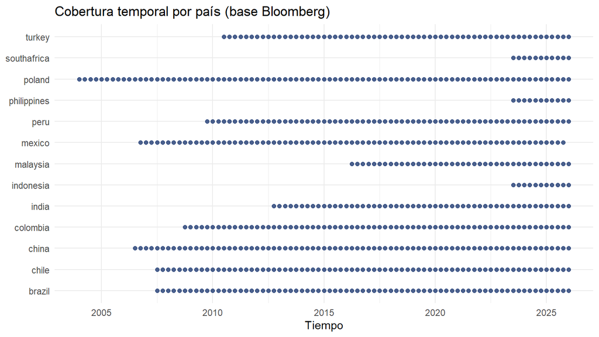

```r
ggplot(dat, aes(x = tnum, y = country)) +
  geom_point(size = 1.6, alpha = .8, color = "#1f3b73") +
  labs(x = "Tiempo", y = NULL, title = "Cobertura temporal por país (base Bloomberg)") +
  theme_minimal(base_size = 11)
```

# 3 Núcleo del modelo (M1–M5)

`M1`: fragilidad y cola sin interacción. `M2`: agrega la interacción (FE país+tiempo). `M3`: agrega controles domésticos. `M4`: dependiente en log. `M5`: FE país con `VIX` explícito.

```r
run_main <- function(pdat) {
  list(
    M1 = plm(EMBI_bps ~ JLoss_c + GaR_c,                               data = pdat, model = "within", effect = "twoways"),
    M2 = plm(EMBI_bps ~ JLoss_c + GaR_c + JxG_c,                       data = pdat, model = "within", effect = "twoways"),
    M3 = plm(as.formula(paste("EMBI_bps ~ JLoss_c + GaR_c + JxG_c +", CTRL)),
             data = pdat, model = "within", effect = "twoways"),
    M4 = plm(as.formula(paste("lnEMBI  ~ JLoss_c + GaR_c + JxG_c +", CTRL)),
             data = pdat, model = "within", effect = "twoways"),
    M5 = plm(as.formula(paste("EMBI_bps ~ JLoss_c + GaR_c + JxG_c + VIX +", CTRL)),
             data = pdat, model = "within", effect = "individual")
  )
}
mods <- run_main(pan)

cmap <- c("JLoss_c"="JLoss", "GaR_c"="GaR (pp)", "JxG_c"="JLoss × GaR", "VIX"="VIX",
          "debt_gdp"="Deuda/PIB", "fisc_bal"="Balance fiscal/PIB",
          "res_gdp"="Reservas/PIB", "ca_gdp"="Cuenta corriente/PIB",
          "infl_yoy"="Inflación YoY", "reer"="REER")

modelsummary(mods,
  vcov = lapply(mods, DK),
  coef_map = cmap,
  stars = c('*'=.1,'**'=.05,'***'=.01),
  gof_omit = "AIC|BIC|Log.Lik|RMSE|Adj",
  notes = "SE Driscoll-Kraay. M1-M4: FE país+tiempo. M5: FE país + VIX explícito.",
  title = "Tabla 1. Núcleo — base final Bloomberg (13 países)")
```

Tabla 1. Núcleo — base final Bloomberg (13 países)

|  | M1 | M2 | M3 | M4 | M5 |
| --- | --- | --- | --- | --- | --- |
| JLoss | 4.588*** | 4.604*** | 2.814*** | -0.000 | 3.146*** |
|  | (1.060) | (1.008) | (0.944) | (0.005) | (0.912) |
| GaR (pp) | -4.277 | -4.069 | -4.513*** | -0.030** | -5.450*** |
|  | (2.805) | (2.740) | (1.742) | (0.012) | (1.134) |
| JLoss × GaR |  | -0.176 | -0.188 | 0.001 | -0.005 |
|  |  | (0.240) | (0.146) | (0.001) | (0.101) |
| VIX |  |  |  |  | 1.730*** |
|  |  |  |  |  | (0.499) |
| Deuda/PIB |  |  | -2.704*** | -0.009*** | -1.792*** |
|  |  |  | (0.576) | (0.004) | (0.483) |
| Balance fiscal/PIB |  |  | -7.475*** | -0.070*** | -3.161 |
|  |  |  | (2.095) | (0.013) | (2.088) |
| Reservas/PIB |  |  | -2.929* | -0.016* | -1.646 |
|  |  |  | (1.550) | (0.009) | (1.673) |
| Cuenta corriente/PIB |  |  | -6.994*** | -0.045*** | -7.570*** |
|  |  |  | (1.473) | (0.008) | (1.954) |
| Inflación YoY |  |  | -1.224 | -0.006** | -0.622 |
|  |  |  | (1.006) | (0.002) | (0.722) |
| REER |  |  | -2.610*** | -0.012*** | -2.293*** |
|  |  |  | (0.482) | (0.003) | (0.450) |
| Num.Obs. | 721 | 721 | 614 | 614 | 614 |
| R2 | 0.107 | 0.109 | 0.407 | 0.330 | 0.486 |
| Std.Errors | M1 | M2 | M3 | M4 | M5 |

* p < 0.1, ** p < 0.05, *** p < 0.01  
SE Driscoll-Kraay. M1-M4: FE país+tiempo. M5: FE país + VIX explícito.

# 4 Efecto marginal de JLoss según el riesgo de cola

[figure not shown]

```r
marginal_df <- function(m, d) {
  V  <- DK(m); b <- coef(m)
  bJ <- b["JLoss_c"]; bI <- b["JxG_c"]
  vJ <- V["JLoss_c","JLoss_c"]; vI <- V["JxG_c","JxG_c"]; cJI <- V["JLoss_c","JxG_c"]
  mu <- mean(d$GaR_pp, na.rm = TRUE)
  grid <- seq(quantile(d$GaR_pp, .05, na.rm = TRUE), quantile(d$GaR_pp, .95, na.rm = TRUE), length.out = 100)
  dev <- grid - mu
  me  <- bJ + bI * dev
  se  <- sqrt(vJ + dev^2 * vI + 2 * dev * cJI)
  data.frame(GaR = grid, me = me, lo = me - 1.96*se, hi = me + 1.96*se)
}
mdf <- marginal_df(mods$M3, dat)

ggplot(mdf, aes(GaR, me)) +
  geom_hline(yintercept = 0, color = "grey50") +
  geom_ribbon(aes(ymin = lo, ymax = hi), alpha = .15, fill = "#1f3b73") +
  geom_line(linewidth = 1, color = "#1f3b73") +
  scale_x_reverse() +
  labs(x = "GaR (pp) — izquierda = mayor riesgo de cola",
       y = "∂EMBI/∂JLoss (pb por unidad de JLoss)",
       title = "Amplificación supra-aditiva del riesgo soberano (M3)",
       subtitle = "Cuanto más severa la cola (izquierda), mayor el efecto de la fragilidad") +
  theme_minimal(base_size = 12)
```

# 5 Diagnósticos del panel

```r
diag_table <- function(m2, pdat) {
  cd <- pcdtest(m2, test = "cd")                                  # dependencia transversal
  bg <- pbgtest(m2)                                               # autocorrelación
  re <- plm(EMBI_bps ~ JLoss_c + GaR_c + JxG_c, data = pdat, model = "random", effect = "twoways")
  ha <- phtest(m2, re)                                            # Hausman FE vs RE
  data.frame(
    test = c("Pesaran CD (dep. transversal)", "Wooldridge (autocorr.)", "Hausman (FE vs RE)"),
    estadistico = round(c(cd$statistic, bg$statistic, ha$statistic), 3),
    p_valor = round(c(cd$p.value, bg$p.value, ha$p.value), 4)
  )
}
kable(diag_table(mods$M2, pan), caption = "Diagnósticos del panel (sobre M2)") %>%
  kable_styling(full_width = FALSE)
```

Diagnósticos del panel (sobre M2)

| test | estadistico | p_valor |
| --- | --- | --- |
| Pesaran CD (dep. transversal) | -2.835 | 0.0046 |
| Wooldridge (autocorr.) | 584.443 | 0.0000 |
| Hausman (FE vs RE) | 3.796 | 0.2844 |

```r
aux <- lm(EMBI_bps ~ JLoss + GaR_pp + debt_gdp + fisc_bal + res_gdp + ca_gdp + infl_yoy + reer + VIX, data = dat)
cat("VIF (regla práctica: >10 problemático):\n"); print(round(vif(aux), 2))
```

```
## VIF (regla práctica: >10 problemático):
```

```
##    JLoss   GaR_pp debt_gdp fisc_bal  res_gdp   ca_gdp infl_yoy     reer
##     1.75     1.41     2.21     2.53     2.46     1.79     1.37     1.68
##      VIX
##     1.34
```

# 6 Robustez de θ (interacción JLoss × GaR)

## 6.1 Variantes de error estándar

```r
se_compare <- function(m) {
  variants <- list(
    "Driscoll-Kraay" = DK(m),
    "Cluster país"   = vcovHC(m, type = "HC1", cluster = "group"),
    "Cluster tiempo" = vcovHC(m, type = "HC1", cluster = "time"),
    "Arellano (HAC)" = vcovHC(m, method = "arellano", type = "HC1")
  )
  sapply(variants, function(v) {
    ct <- coeftest(m, vcov = v)["JxG_c", ]
    c(coef = round(ct[1],3), se = round(ct[2],3), t = round(ct[3],2), p = round(ct[4],4))
  })
}
kable(t(se_compare(mods$M3)), caption = "θ bajo distintas matrices de varianza (M3)") %>%
  kable_styling(full_width = FALSE)
```

θ bajo distintas matrices de varianza (M3)

|  | coef.Estimate | se.Std. Error | t.t value | p.Pr(>&#124;t&#124;) |
| --- | --- | --- | --- | --- |
| Driscoll-Kraay | -0.188 | 0.146 | -1.29 | 0.1976 |
| Cluster país | -0.188 | 0.108 | -1.74 | 0.0827 |
| Cluster tiempo | -0.188 | 0.106 | -1.77 | 0.0771 |
| Arellano (HAC) | -0.188 | 0.108 | -1.74 | 0.0827 |

## 6.2 Excluyendo COVID (≤ 2019)

```r
pan_nc <- pdata.frame(subset(dat, post2020 == 0), index = c("country","tnum"))
m_nc <- plm(as.formula(paste("EMBI_bps ~ JLoss_c + GaR_c + JxG_c +", CTRL)),
            data = pan_nc, model = "within", effect = "twoways")
printCoefmat(coeftest(m_nc, vcov = DK(m_nc)))
```

```
##          Estimate Std. Error t value              Pr(>|t|)
## JLoss_c   1.68687    1.44011  1.1713              0.242324
## GaR_c    -6.10406    1.09310 -5.5842         0.00000004985 ***
## JxG_c    -0.25520    0.34267 -0.7448              0.456963
## debt_gdp -0.10230    0.64674 -0.1582              0.874416
## fisc_bal -5.09415    1.11493 -4.5690         0.00000698225 ***
## res_gdp  -3.34999    1.07453 -3.1176              0.001987 **
## ca_gdp   -5.06717    1.05265 -4.8137         0.00000227927 ***
## infl_yoy  4.45126    2.01268  2.2116              0.027694 *
## reer     -2.88301    0.32109 -8.9787 < 0.00000000000000022 ***
## ---
## Signif. codes:  0 '***' 0.001 '**' 0.01 '*' 0.05 '.' 0.1 ' ' 1
```

## 6.3 Excluyendo todos los trimestres de crisis (GFC + COVID)

La definición completa del Capítulo 2 —GFC 2008Q4-2009Q4 y pandemia 2020Q1-2021Q4 fuera, recentrando `JLoss`/`GaR` en la submuestra— es la que sostiene la Tabla 2.3 de la tesis.

```r
CRISIS_Q <- c("2008Q4","2009Q1","2009Q2","2009Q3","2009Q4",
              "2020Q1","2020Q2","2020Q3","2020Q4","2021Q1","2021Q2","2021Q3","2021Q4")
dat_sc <- subset(dat, !(quarter %in% CRISIS_Q))
dat_sc$JLoss_c <- dat_sc$JLoss - mean(dat_sc$JLoss)
dat_sc$GaR_c   <- dat_sc$GaR_pp - mean(dat_sc$GaR_pp)
dat_sc$JxG_c   <- dat_sc$JLoss_c * dat_sc$GaR_c
pan_sc <- pdata.frame(dat_sc, index = c("country","tnum"))
m_sc <- plm(as.formula(paste("EMBI_bps ~ JLoss_c + GaR_c + JxG_c +", CTRL)),
            data = pan_sc, model = "within", effect = "twoways")
printCoefmat(coeftest(m_sc, vcov = DK(m_sc)))
```

```
##          Estimate Std. Error t value       Pr(>|t|)
## JLoss_c   2.77733    1.33526  2.0800      0.0381278 *
## GaR_c    -5.77044    1.71991 -3.3551      0.0008650 ***
## JxG_c    -0.68089    0.31369 -2.1706      0.0305158 *
## debt_gdp -1.97162    0.50741 -3.8857      0.0001184 ***
## fisc_bal -9.58200    1.53987 -6.2226 0.000000001178 ***
## res_gdp  -0.58451    1.42869 -0.4091      0.6826573
## ca_gdp   -6.86532    1.43479 -4.7849 0.000002367824 ***
## infl_yoy -0.78776    0.78729 -1.0006      0.3175981
## reer     -2.17639    0.46901 -4.6404 0.000004645369 ***
## ---
## Signif. codes:  0 '***' 0.001 '**' 0.01 '*' 0.05 '.' 0.1 ' ' 1
```

## 6.4 Especificación dinámica (EMBI rezagado)

```r
dat$EMBI_lag <- ave(dat$EMBI_bps, dat$country, FUN = function(x) c(NA, head(x, -1)))
pan_dyn <- pdata.frame(dat, index = c("country","tnum"))
m_dyn <- plm(as.formula(paste("EMBI_bps ~ EMBI_lag + JLoss_c + GaR_c + JxG_c +", CTRL)),
             data = pan_dyn, model = "within", effect = "twoways")
printCoefmat(coeftest(m_dyn, vcov = DK(m_dyn)))
```

```
##           Estimate Std. Error t value              Pr(>|t|)
## EMBI_lag  0.862307   0.029923 28.8180 < 0.00000000000000022 ***
## JLoss_c   1.112425   0.323785  3.4357             0.0006406 ***
## GaR_c    -0.848524   0.588271 -1.4424             0.1498198
## JxG_c    -0.122927   0.060691 -2.0254             0.0433562 *
## debt_gdp -0.971894   0.197515 -4.9206           0.000001176 ***
## fisc_bal -2.191110   0.783065 -2.7981             0.0053401 **
## res_gdp  -0.272540   0.443728 -0.6142             0.5393616
## ca_gdp   -2.646228   0.586853 -4.5092           0.000008130 ***
## infl_yoy -0.986500   0.410074 -2.4057             0.0165082 *
## reer     -0.563886   0.176558 -3.1938             0.0014936 **
## ---
## Signif. codes:  0 '***' 0.001 '**' 0.01 '*' 0.05 '.' 0.1 ' ' 1
```

## 6.5 Cola medida con Expected Shortfall (ES)

```r
dat$ES_pp_c <- dat$ES_pp - mean(dat$ES_pp, na.rm = TRUE)
dat$JxES_c  <- dat$JLoss_c * dat$ES_pp_c
pan_es <- pdata.frame(dat, index = c("country","tnum"))
m_es <- plm(as.formula(paste("EMBI_bps ~ JLoss_c + ES_pp_c + JxES_c +", CTRL)),
            data = pan_es, model = "within", effect = "twoways")
printCoefmat(coeftest(m_es, vcov = DK(m_es)))
```

```
##          Estimate Std. Error t value      Pr(>|t|)
## JLoss_c   2.58572    0.93039  2.7792     0.0056528 **
## ES_pp_c  -4.60396    1.87731 -2.4524     0.0145273 *
## JxES_c   -0.19335    0.14367 -1.3458     0.1789862
## debt_gdp -2.68731    0.57185 -4.6994 0.00000337009 ***
## fisc_bal -7.54461    2.24086 -3.3668     0.0008183 ***
## res_gdp  -3.05215    1.54616 -1.9740     0.0489247 *
## ca_gdp   -6.73433    1.51165 -4.4549 0.00001034180 ***
## infl_yoy -1.17363    1.01887 -1.1519     0.2499077
## reer     -2.58207    0.47670 -5.4166 0.00000009416 ***
## ---
## Signif. codes:  0 '***' 0.001 '**' 0.01 '*' 0.05 '.' 0.1 ' ' 1
```

# 7 Del modelo agrupado a los efectos fijos

```r
run_battery <- function(pdat) {
  list(
    "(1) Solo JLoss"          = plm(EMBI_bps ~ JLoss_c,                 pdat, model = "pooling"),
    "(2) Solo GaR"            = plm(EMBI_bps ~ GaR_c,                   pdat, model = "pooling"),
    "(3) JLoss + GaR"         = plm(EMBI_bps ~ JLoss_c + GaR_c,         pdat, model = "pooling"),
    "(4) + interac. (sin FE)" = plm(EMBI_bps ~ JLoss_c + GaR_c + JxG_c, pdat, model = "pooling"),
    "(5) FE país"             = plm(EMBI_bps ~ JLoss_c + GaR_c + JxG_c, pdat, model = "within", effect = "individual"),
    "(6) FE tiempo"           = plm(EMBI_bps ~ JLoss_c + GaR_c + JxG_c, pdat, model = "within", effect = "time"),
    "(7) FE país + tiempo"    = plm(EMBI_bps ~ JLoss_c + GaR_c + JxG_c, pdat, model = "within", effect = "twoways")
  )
}
bat <- run_battery(pan)
modelsummary(bat, vcov = lapply(bat, DK),
  coef_map = c("JLoss_c"="JLoss","GaR_c"="GaR (pp)","JxG_c"="JLoss × GaR"),
  stars = c('*'=.1,'**'=.05,'***'=.01), gof_omit = "AIC|BIC|Log.Lik|RMSE|Adj",
  title = "Tabla 2. Del modelo agrupado a los efectos fijos")
```

Tabla 2. Del modelo agrupado a los efectos fijos

|  | (1) Solo JLoss | (2) Solo GaR | (3) JLoss + GaR | (4) + interac. (sin FE) | (5) FE país | (6) FE tiempo | (7) FE país + tiempo |
| --- | --- | --- | --- | --- | --- | --- | --- |
| JLoss | 9.254*** |  | 8.399*** | 8.370*** | 6.024*** | 8.614*** | 4.604*** |
|  | (1.283) |  | (1.146) | (1.181) | (1.125) | (1.331) | (1.008) |
| GaR (pp) |  | -9.458*** | -8.149*** | -7.999*** | -5.911*** | -10.415*** | -4.069 |
|  |  | (1.714) | (1.924) | (1.699) | (1.599) | (2.551) | (2.740) |
| JLoss × GaR |  |  |  | -0.093 | -0.213 | -0.159 | -0.176 |
|  |  |  |  | (0.386) | (0.240) | (0.452) | (0.240) |
| Num.Obs. | 721 | 721 | 721 | 721 | 721 | 721 | 721 |
| R2 | 0.162 | 0.114 | 0.246 | 0.246 | 0.276 | 0.188 | 0.109 |
| Std.Errors | (1) Solo JLoss | (2) Solo GaR | (3) JLoss + GaR | (4) + interac. (sin FE) | (5) FE país | (6) FE tiempo | (7) FE país + tiempo |

* p < 0.1, ** p < 0.05, *** p < 0.01

# 8 Factores globales

La base anterior comparaba contra los índices agregados del paper de JLoss (`X_dom_idx`, `X_global_idx`), que no existen en la reconstrucción Bloomberg. El equivalente que sí trae esta base son los factores financieros globales de la propia tesis (VIX, tasa a 10 años de EE.UU., spread de high yield) — la especificación M3 de `tabla_theta_bbg.csv`.

```r
mods_glob <- list(
  "+ UST10Y + US_HY (FE país)" = plm(EMBI_bps ~ JLoss_c + GaR_c + JxG_c + UST10Y_log + US_HY_spread_log,
                                      data = pdata.frame(subset(dat, !is.na(UST10Y_log) & !is.na(US_HY_spread_log)),
                                                          index = c("country","tnum")),
                                      model = "within", effect = "individual"),
  "+ VIX + UST10Y + US_HY (FE país)" = plm(EMBI_bps ~ JLoss_c + GaR_c + JxG_c + VIX + UST10Y_log + US_HY_spread_log,
                                      data = pdata.frame(subset(dat, !is.na(VIX) & !is.na(UST10Y_log) & !is.na(US_HY_spread_log)),
                                                          index = c("country","tnum")),
                                      model = "within", effect = "individual")
)
modelsummary(mods_glob, vcov = lapply(mods_glob, DK),
  coef_map = c("JLoss_c"="JLoss", "GaR_c"="GaR (pp)", "JxG_c"="JLoss × GaR", "VIX"="VIX",
               "UST10Y_log"="UST 10Y (log)", "US_HY_spread_log"="Spread HY EE.UU. (log)"),
  stars = c('*'=.1,'**'=.05,'***'=.01), gof_omit = "AIC|BIC|Log.Lik|RMSE|Adj",
  notes = "SE Driscoll-Kraay. FE país (los factores globales no varían por país, no admiten FE de tiempo).",
  title = "Tabla 3. θ controlando por factores financieros globales")
```

Tabla 3. θ controlando por factores financieros globales

|  | + UST10Y + US_HY (FE país) | + VIX + UST10Y + US_HY (FE país) |
| --- | --- | --- |
| JLoss | 5.987*** | 5.724*** |
|  | (0.998) | (0.951) |
| GaR (pp) | -5.148*** | -4.588*** |
|  | (1.634) | (1.646) |
| JLoss × GaR | 0.033 | 0.043 |
|  | (0.188) | (0.182) |
| VIX |  | 0.866 |
|  |  | (1.020) |
| UST 10Y (log) | -10.348 | -11.646 |
|  | (8.784) | (8.333) |
| Spread HY EE.UU. (log) | 59.726*** | 48.839*** |
|  | (13.798) | (17.594) |
| Num.Obs. | 721 | 721 |
| R2 | 0.355 | 0.358 |
| Std.Errors | + UST10Y + US_HY (FE país) | + VIX + UST10Y + US_HY (FE país) |

* p < 0.1, ** p < 0.05, *** p < 0.01  
SE Driscoll-Kraay. FE país (los factores globales no varían por país, no admiten FE de tiempo).

# 9 Síntesis: triangulación de θ

```r
get_theta <- function(m, label) {
  ct <- coeftest(m, vcov = DK(m))
  data.frame(modelo = label,
             theta = ct["JxG_c","Estimate"],
             se = ct["JxG_c","Std. Error"],
             p = ct["JxG_c","Pr(>|t|)"])
}
synth <- bind_rows(
  get_theta(mods$M2,        "M2 — FE país+tiempo"),
  get_theta(mods$M3,        "M3 — + controles"),
  get_theta(mods$M5,        "M5 — FE país + VIX"),
  get_theta(m_nc,           "Sin COVID (≤2019)"),
  get_theta(m_sc,           "Sin crisis (GFC+COVID)"),
  get_theta(m_dyn,          "Dinámico (EMBI rezagado)"),
  get_theta(mods_glob[[1]], "+ factores globales (FE país)")
) %>% mutate(lo = theta - 1.96*se, hi = theta + 1.96*se)

kable(synth %>% mutate(across(c(theta, se, p), ~round(., 4))),
      caption = "Coeficiente θ de JLoss × GaR a través de las especificaciones") %>%
  kable_styling(full_width = FALSE)
```

Coeficiente θ de JLoss × GaR a través de las especificaciones

modelo

theta

se

p

lo

hi

M2 — FE país+tiempo

-0.1756

0.2404

0.4653

-0.6466855

0.2955063

M3 — + controles

-0.1877

0.1455

0.1976

-0.4729672

0.0975023

M5 — FE país + VIX

-0.0045

0.1013

0.9642

-0.2030570

0.1939702

Sin COVID (≤2019)

-0.2552

0.3427

0.4570

-0.9268358

0.4164280

Sin crisis (GFC+COVID)

-0.6809

0.3137

0.0305

-1.2957205

-0.0660674

Dinámico (EMBI rezagado)

-0.1229

0.0607

0.0434

-0.2418822

-0.0039722

- factores globales (FE país)

0.0326

0.1882

0.8624

-0.3362968

0.4015534

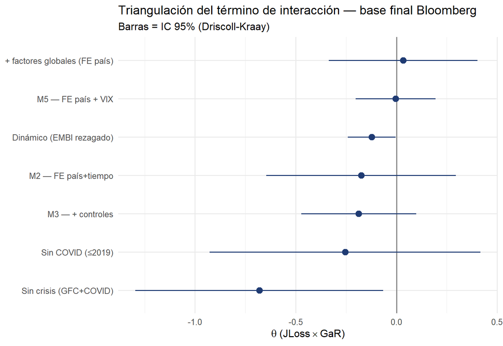

```r
ggplot(synth, aes(x = theta, y = reorder(modelo, theta))) +
  geom_vline(xintercept = 0, color = "grey50") +
  geom_pointrange(aes(xmin = lo, xmax = hi), color = "#1f3b73") +
  labs(x = expression(theta ~ "(JLoss" %*% "GaR)"), y = NULL,
       title = "Triangulación del término de interacción — base final Bloomberg",
       subtitle = "Barras = IC 95% (Driscoll-Kraay)") +
  theme_minimal(base_size = 12)
```

# 10 Notas

- **Base:** `bbg/Panel_bloomberg.csv` únicamente. No se cargan otras bases. Muestra de estimación: 13 países con EMBI+JLoss+GaR simultáneos (Argentina, Egipto, Rusia y Pakistán quedan fuera — no tienen EMBI Global Diversified ni, en tres de los cuatro, GaR; ver `bbg/cobertura_panel_bbg.csv`).
- **Escala:** `GaR_pp = GaR × 100` (puntos porcentuales); `EMBI_bps` en puntos base.
- **Identificación:** efectos fijos de país y tiempo; los efectos principales se interpretan en la media porque `JLoss` y `GaR` están centrados.
- **Inferencia:** errores Driscoll-Kraay por defecto (robustos a dependencia transversal y autocorrelación), con variantes de robustez reportadas.
- **La batería completa** (4 modelos × 3 efectos fijos × 2 muestras = Tabla 2.3 de la tesis) vive en `Regresiones_panel_extended_v3.Rmd`; este documento es un núcleo más compacto con diagnósticos formales adicionales (Hausman, VIF) sobre la misma base.